# Introduction to Pattern Sequence based Forecasting (PSF) algorithm

Neeraj Bokde, Gualberto Asencio-Cortes and Francisco Martinez-Alvarez

2016-08-18

## Introduction

The Algorithm Pattern Sequence based Forecasting (PSF) was first proposed by Martinez Alvarez, et al., 2008 and then modified and suggested improvement by Martinez Alvarez, et al., 2011. The technical detailes are mentioned in referenced articles. PSF algorithm consists of various statistical operations like:

- Data Normalization/ Denormalization
- Calculation of optimum Window size (W)
- Calculation of optimum cluster size (k)
- Pattern Sequence based Forecasting
- RMSE/MAE Calculation, etc..

## Example

This section discusses about the examples to introduce the use of the PSF package and to compare it with auto.arima() and ets() functions, which are well accepted functions in the R community working over time series forecasting techniques. The data used in this example are ’nottem’ and ’sunspots’ which are the standard time series dataset available in R. The ’nottem’ dataset is the average air temperatures at Nottingham Castle in degrees Fahrenheit, collected for 20 years, on monthly basis.

#### Install library

Download the Package and install with instruction:

```r
library(PSF)
```

#### Prediction results for ’nottem’ dataset with psf() function.

```r
a <- psf(data = nottem, n.ahead = 12)
a
```

```
## $predictions
##  [1] 39.225 39.600 42.600 47.500 53.550 58.975 63.275 61.200 57.275 49.425
## [11] 43.475 39.250
##
## $k
## [1] 3
##
## $w
## [1] 1
```

#### Prediction results for ’sunspots’ dataset with psf() function.

```r
b <- psf(data = sunspots, n.ahead = 48)
b
```

```
## $predictions
##  [1] 45.80000 45.66667 43.53333 50.40000 43.03333 46.46667 35.63333
##  [8] 45.56667 46.16667 40.76667 35.33333 37.83333 33.53000 37.93000
## [15] 36.22000 40.39000 31.84000 30.03000 27.46000 24.65000 23.23000
## [22] 27.61000 24.79000 18.80000 16.58333 16.90000 19.76667 14.59167
## [29] 18.86667 16.30000 14.65000 19.43333 13.65000 14.74167 21.50000
## [36] 15.69167 16.27143 15.01429 11.84286 13.35714 14.88571 15.05000
## [43] 14.47857 17.22857 17.25714 21.75714 23.02857 21.10714
##
## $k
## [1] 2
##
## $w
## [1] 6
```

To represent the prediction performance in plot format, the psf_plot() function is used as shown in the following code.

#### Plot for ‘nottem’ dataset

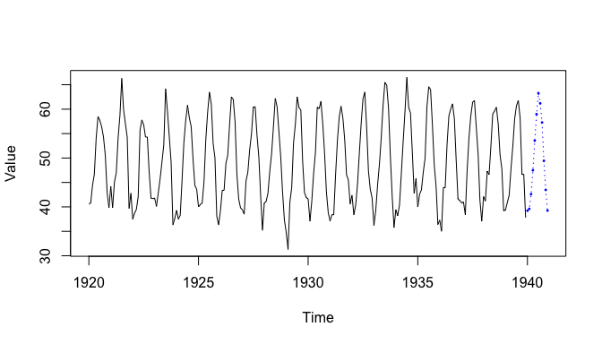

```r
psf_plot(data = nottem, predictions = a$predictions)
```

#### Plot for ‘sunspots’ dataset

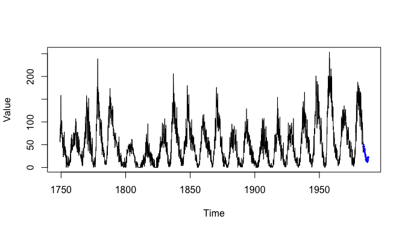

```r
psf_plot(data = sunspots, predictions = b$predictions)
```

## Comparison of `psf()` with `auto.arima()` and `ets()` functions:

Example below shows the comparisons for `psf()`, `auto.arima()` and `ets()` functions when using the Root Mean Square Error (RMSE) parameter as metric, for ’sunspots’ dataset. In order to avail more accurate and robust comparison results, error values are calculated for 5 times and the mean value of error values for methods under comparison are also shown. These values clearly state that ‘psf()’ function is able to outperform the comparative time series prediction methods. Additionally, the reader might want to refer to the results published in the original work Martinez Alvarez et al. (2011), in which it was shown that PSF outperformed many different methods when applied to electricity prices and demand forecasting.

```r
library(PSF)
library(forecast)
options(warn=-1)

## Consider data `sunspots` with removal of last years's readings
# Training Data
x <- sunspots[1:2772]

# Test Data
y <- sunspots[2773:2820]

PSF <- NULL
ARIMA <- NULL
ETS <- NULL

for(i in 1:5)
{
  set.seed(i)

  # for PSF
  a <- psf(data = x, n.ahead = 48)$predictions

  # for ARIMA
  b <- forecast(auto.arima(x), 48)$mean

  # for ets
  c <- as.numeric(forecast(ets(x), 48)$mean)

  ## For Error Calculations
  # Error for PSF
  PSF[i] <- sqrt(mean((y - a)^2))
  # Error for ARIMA
  ARIMA[i] <- sqrt(mean((y - b)^2))
  # Error for ETS
  ETS[i] <- sqrt(mean((y - c)^2))

}

## Error values for PSF
  PSF
```

```
## [1] 61.08512 61.08512 61.08512 61.08512 61.08512
```

```r
  mean(PSF)
```

```
## [1] 61.08512
```

```r
## Error values for ARIMA
  ARIMA
```

```
## [1] 103.0719 103.0719 103.0719 103.0719 103.0719
```

```r
  mean(ARIMA)
```

```
## [1] 103.0719
```

```r
## Error values for ETS
  ETS
```

```
## [1] 70.66554 70.66554 70.66554 70.66554 70.66554
```

```r
  mean(ETS)
```

```
## [1] 70.66554
```

## References

Martínez-Álvarez, F., Troncoso, A., Riquelme, J.C. and Ruiz, J.S.A., 2008, December. LBF: A labeled-based forecasting algorithm and its application to electricity price time series. In Data Mining, 2008. ICDM’08. Eighth IEEE International Conference on (pp. 453-461). IEEE.

Martinez Alvarez, F., Troncoso, A., Riquelme, J.C. and Aguilar Ruiz, J.S., 2011. Energy time series forecasting based on pattern sequence similarity. Knowledge and Data Engineering, IEEE Transactions on, 23(8), pp.1230-1243.